# Impacts of kelp removal on POM content on beaches around Cape Town

# Methods and Materials

## Study Sites:

Our study area consisted of 5 beaches around the city of Cape Town. These include Strandfontein (18° 33’ 28.819" E, 34° 5’ 11.626" S), Muizenberg (18°28’13.8“E, 34°06’30.5”S), Fish Hoek (18° 26’ 5.71" E, 34° 8’ 9.124" S), Hout Bay East (18°21’34.0“E, 34°02’50.0”S) and Hout Bay West (18°20’59.4“E, 34°02’46.4”S). These sites are divided up into ‘cleared’ and ‘non-cleared’ sections, where the ‘cleared’ sections are recognised by the City of Cape Town as kelp removal zones. Kelp is removed from Strandfontein beach on a seasonal basis, and a regular basis from the four remaining sites.

[figure not shown]

```r
sites <- read.csv("sites.csv", sep=";")

cape_point1 <-  get_map(location = c(lon = 18.6, lat = -34.2),
                        zoom = 10, maptype = 'satellite')
ggmap(cape_point1)
```

[figure not shown]

```r
cp1 <- ggmap(cape_point1) +
  geom_point(data = sites, aes(x = long , y = lat ),
             colour = "red", size =  2.5) +
  #coord_equal(xlim = c(18.2, 19.0), ylim = c(-34.5, -33.8), expand = FALSE) +
  labs(y = "Latitude(°S)", x = "Longitude(°E)", title = "Site Map")

cp2 <- cp1 +
  geom_text(data = sites,
            aes(long , lat , label = site),
            hjust = 0, vjust = 0.7,
            size = 4, colour = "white") +
  annotate("text", label = "Hout Bay West",
           x = 18.25, y = -34.11,
           size = 4, colour = "white") +
  theme_bw()+
  coord_cartesian()

cp2
```

## Sampling methods

Both cleared and non-cleared areas of each beach were sampled for POM content in the soil. Transects of various lengths were run perpendicular to the shore, and divided into 5 sections according to the length of the transect on that particular sampling occasion. Soil samples were collected at a depth of 20cm at each of the sections. Samples were taken back to the UWC laboratory, where they were weighed (wet weight), dried, weighed again (dry weight) and placed in a muffle furnace and finally reweighed (burned weight). The difference between the dry weight and burned weight is an estimate of the POM content. Visual observations (metadata) were made regarding the amount of kelp present on the beaches at the time of sampling. These observations were recorded as zero, very low, low, average, above average and extreme. A ranking system was then applied to these observations from 1 to 5, where 1 = zero kelp and 5 representing an above average abundance of kelp.

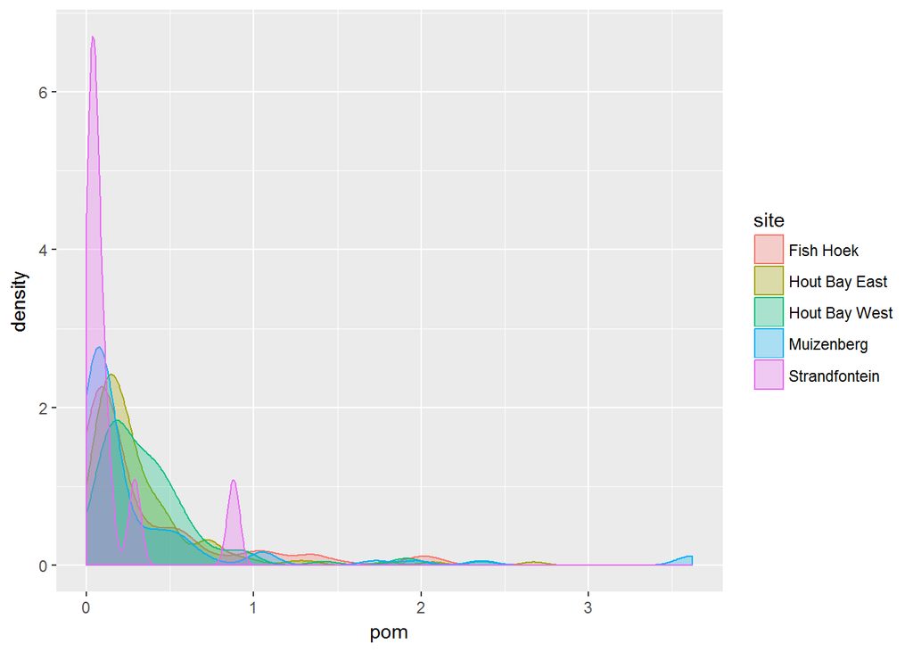

```r
# load  data  -------------------------------------------------------------

pom_data <- read.csv("updated.csv", sep = ";")

# quick visualisation
ggplot(pom_data, aes(x = pom)) +
  geom_density(aes(group = site, colour = site, fill = site),alpha = 0.3)
```

```r
# test for normality
shapiro.test(pom_data$pom)
```

```
##
##  Shapiro-Wilk normality test
##
## data:  pom_data$pom
## W = 0.64458, p-value < 2.2e-16
```

## Statistical methods:

All data was recorded and entered into an Excel spread sheet, which was then converted to a CSV, in order to be read into the R Project for statistical analysis. The Shapiro test for normality was conducted on the data along with homoscedastic tests to determine the distribution and variance of the data. For non-normally distributed data, non-parametric tests such as the Kruskal- Wallis (non-parametric equivalent of an ANOVA) and the Wilcox (non-parametric equivalent of a one-sample t-test) tests were performed. Significant differences at p≤0.05 were analysed using Kruskalmc post hoc analysis in R.

A Wilcox test was used to compare the means of the POM content within cleared and non-cleared areas for all sites.

```r
# wilcox test
compare_means(pom ~ area, data = pom_data, method = "wilcox")
```

| .y. | group1 | group2 | p | p.adj | p.format | p.signif | method |
| --- | --- | --- | --- | --- | --- | --- | --- |
| pom | cleared | non_cleared | 0.03888065 | 0.03888065 | 0.039 | * | Wilcoxon |

```r
# create a graph
# total pom content
plot1 <- ggplot(data = pom_data, aes(x = area, y = pom, fill = area)) +
  geom_boxplot(notch = TRUE)+
  geom_jitter(alpha = 0.3, color = "black") +
  labs(title = "Total POM content",
       x = "Area",
       y = "POM (g)") +
  theme_minimal()
```

A non-parametric Kruskal-Wallis test was used to compare the means of POM content across all sites, and a Kruskalmc post hoc analysis was conducted to identify where the differences lie between sites.

```r
# Kruskal-Wallis test
kruskal.test(pom ~ as.factor(site), data = pom_data)
```

```
##
##  Kruskal-Wallis rank sum test
##
## data:  pom by as.factor(site)
## Kruskal-Wallis chi-squared = 34.619, df = 4, p-value = 5.561e-07
```

```r
# perform Kruskalmc post-hoc test
kruskalmc(pom ~ as.factor(site), data = pom_data)
```

```
## Multiple comparison test after Kruskal-Wallis
## p.value: 0.05
## Comparisons
##                               obs.dif critical.dif difference
## Fish Hoek-Hout Bay East      31.39452     45.85033      FALSE
## Fish Hoek-Hout Bay West      70.92667     50.37064       TRUE
## Fish Hoek-Muizenberg         31.22395     53.79859      FALSE
## Fish Hoek-Strandfontein      91.32333    127.42875      FALSE
## Hout Bay East-Hout Bay West  39.53214     51.08515      FALSE
## Hout Bay East-Muizenberg     62.61847     54.46816       TRUE
## Hout Bay East-Strandfontein 122.71786    127.71288      FALSE
## Hout Bay West-Muizenberg    102.15062     58.32434       TRUE
## Hout Bay West-Strandfontein 162.25000    129.40451       TRUE
## Muizenberg-Strandfontein     60.09938    130.77697      FALSE
```

```r
# create graph
# pom content for each site, both cleared and non-cleared
plot2 <- ggplot(data = pom_data, aes(x = site, y = pom, fill = area)) +
  geom_boxplot( notch = TRUE)+
  geom_jitter(alpha = 0.3, color = "black")+
  labs(title = "POM content per site",
       x = "Site",
       y = "POM (g)") +
  theme_minimal()
```

To determine whether POM content changes over time, the site Strandfontein was removed due to it only being sampled once, whereas the other sites were sampled multiple times another Kruskal-Wallis test was run for POM as a factor of month, and the Kruskalmc post hoc test identified the months where a significant difference was observed.

```r
# removing the site Strandfontein due to it only being sampled once
time <- pom_data[-c(21:30), ]

# Kruskal-Wallis
kruskal.test(pom ~ as.factor(month), data = time)
```

```
##
##  Kruskal-Wallis rank sum test
##
## data:  pom by as.factor(month)
## Kruskal-Wallis chi-squared = 17.931, df = 2, p-value = 0.0001278
```

```r
# perform Kruskalmc post-hoc test
kruskalmc(pom ~ as.factor(month), data = time)
```

```
## Multiple comparison test after Kruskal-Wallis
## p.value: 0.05
## Comparisons
##            obs.dif critical.dif difference
## Apr-Feb   22.29425     64.05939      FALSE
## Apr-Mar   55.01370     31.11295       TRUE
## Feb -Mar  32.71944     64.70571      FALSE
```

```r
# create graph
plot3 <- ggplot(data = time, aes(x = month, y = pom, fill = area)) +
  geom_boxplot( notch = TRUE) +
  geom_jitter(alpha = 0.3, color = "black") +
  labs(title = "Monthly POM content",
       x = "Site",
       y = "POM (g)") +
  theme_minimal()
```

For the metadata, in order to determine if transect lengths differed per area (cleared and non-cleared), a Wilcox test was run.

```r
meta <- read.csv2("metadata.csv")

meta_long <- meta %>%
  gather(key = "variable", value = "value", -site, -date, -month, -beach_cast_cleared, - beach_cast_noncleared)

#test for homoscedasticity
meta_long %>%
  #group_by(site) %>%
  summarise(meta_long_var = var(value))
```

| meta_long_var |
| --- |
| 265.5532 |

```r
# wilcox test
compare_means(value ~ variable, data = meta_long, method = "wilcox")
```

| .y. | group1 | group2 | p | p.adj | p.format | p.signif | method |
| --- | --- | --- | --- | --- | --- | --- | --- |
| value | cleared_transect | non_cleared_transect | 1.059064e-01 | 1.059064e-01 | 0.1059 | ns | Wilcoxon |
| value | cleared_transect | cl. | 2.089114e-17 | 8.356455e-17 | <2e-16 | **** | Wilcoxon |
| value | cleared_transect | non. | 1.209609e-17 | 7.257651e-17 | <2e-16 | **** | Wilcoxon |
| value | non_cleared_transect | cl. | 2.147475e-17 | 8.356455e-17 | <2e-16 | **** | Wilcoxon |
| value | non_cleared_transect | non. | 1.244427e-17 | 7.257651e-17 | <2e-16 | **** | Wilcoxon |
| value | cl. | non. | 7.699827e-03 | 1.539965e-02 | 0.0077 | ** | Wilcoxon |

```r
# total transect length
plot4 <- ggplot(data = meta_long, aes(x = variable, y = value, fill = variable)) +
  geom_boxplot( notch = TRUE)+
  geom_jitter(alpha = 0.3, color = "black") +
  labs(title = "Total transect lengths",
       x = "area",
       y = "transect length (m)") +
  theme_minimal()
```

Differences in sites for cleared areas were identified by running a Kruskal-Wallis test as well as the Kruskal post hoc test.

```r
sum_cleared_trans <-  meta %>%
  group_by(site) %>%
  summarise(mn_cleared = mean(cleared_transect),
            med_cleared = median(cleared_transect),
            min_cleared = min(cleared_transect),
            max_cleared = max(cleared_transect),
            sd_cleared = sd(cleared_transect),
            mn_cl_rank = mean(cl.))

# Kruskal-Wallis
kruskal.test(cleared_transect ~ as.factor(site), data = meta)
```

```
##
##  Kruskal-Wallis rank sum test
##
## data:  cleared_transect by as.factor(site)
## Kruskal-Wallis chi-squared = 6.5546, df = 4, p-value = 0.1614
```

```r
# perform Kruskalmc post-hoc test
kruskalmc(cleared_transect ~ as.factor(site), data = meta)
```

```
## Multiple comparison test after Kruskal-Wallis
## p.value: 0.05
## Comparisons
##                                      obs.dif critical.dif difference
## Fish Hoek-Hout Bay East             8.190476     14.60377      FALSE
## Fish Hoek-Hout Bay West             5.483333     16.04353      FALSE
## Fish Hoek-Muizenberg               12.395833     17.20477      FALSE
## Fish Hoek-Strandfontein beach      12.666667     40.58729      FALSE
## Hout Bay East-Hout Bay West         2.707143     16.27111      FALSE
## Hout Bay East-Muizenberg            4.205357     17.41719      FALSE
## Hout Bay East-Strandfontein beach  20.857143     40.67778      FALSE
## Hout Bay West -Muizenberg           6.912500     18.64090      FALSE
## Hout Bay West -Strandfontein beach 18.150000     41.21659      FALSE
## Muizenberg-Strandfontein beach     25.062500     41.68232      FALSE
```

```r
# transect lengths for each site, cleared
plot5 <- ggplot(data = meta, aes(x = site, y = cleared_transect)) +
  geom_boxplot(aes(colour = site), notch = TRUE)+
  geom_jitter(alpha = 0.3, color = "black")+
  geom_point(data = sum_cleared_trans, size = 6, shape = 18,
             aes(y = mn_cleared), colour = "goldenrod") +
  labs(title = "cleared",
       x = "Site",
       y = "transect lengths (m)") +
  theme_minimal()
```

Non-cleared areas showed a normal distribution in terms of transect length, and therefore an analysis of variance (ANOVA) test was used to compare the transect lengths between the 5 sites, and a Tukey test was used to identify where the differences lie.

```r
sum_non_cleared_trans <-  meta %>%
  group_by(site) %>%
  summarise(mn_non = mean(non_cleared_transect),
            med_non = median(non_cleared_transect),
            min_non = min(non_cleared_transect),
            max_non = max(non_cleared_transect),
            sd_non = sd(non_cleared_transect),
            mn_non_rank = mean(non.))

# anova
summary(aov(non_cleared_transect ~ as.factor(site), data = meta))
```

```
##                 Df Sum Sq Mean Sq F value Pr(>F)
## as.factor(site)  4  184.3   46.09   2.537 0.0537 .
## Residuals       43  781.1   18.17
## ---
## Signif. codes:  0 '***' 0.001 '**' 0.01 '*' 0.05 '.' 0.1 ' ' 1
```

```r
# perform Tukey post-hoc test
TukeyHSD(aov(non_cleared_transect ~ as.factor(site), data = meta))
```

```
##   Tukey multiple comparisons of means
##     95% family-wise confidence level
##
## Fit: aov(formula = non_cleared_transect ~ as.factor(site), data = meta)
##
## $`as.factor(site)`
##                                           diff         lwr       upr
## Hout Bay East-Fish Hoek             2.50476190  -2.0043275  7.013851
## Hout Bay West -Fish Hoek            0.03333333  -4.9203002  4.986967
## Muizenberg-Fish Hoek                5.30833333  -0.0038468 10.620513
## Strandfontein beach-Fish Hoek       1.93333333 -10.5984784 14.465145
## Hout Bay West -Hout Bay East       -2.47142857  -7.4953299  2.552473
## Muizenberg-Hout Bay East            2.80357143  -2.5741937  8.181337
## Strandfontein beach-Hout Bay East  -0.57142857 -13.1311819 11.988325
## Muizenberg-Hout Bay West            5.27500000  -0.4806020 11.030602
## Strandfontein beach-Hout Bay West   1.90000000 -10.8261149 14.626115
## Strandfontein beach-Muizenberg     -3.37500000 -16.2449174  9.494917
##                                        p adj
## Hout Bay East-Fish Hoek            0.5170590
## Hout Bay West -Fish Hoek           1.0000000
## Muizenberg-Fish Hoek               0.0502468
## Strandfontein beach-Fish Hoek      0.9919965
## Hout Bay West -Hout Bay East       0.6306858
## Muizenberg-Hout Bay East           0.5780777
## Strandfontein beach-Hout Bay East  0.9999338
## Muizenberg-Hout Bay West           0.0864328
## Strandfontein beach-Hout Bay West  0.9929368
## Strandfontein beach-Muizenberg     0.9441166
```

```r
# transect lengths for each site, non_cleared
plot6 <- ggplot(data = meta, aes(x = site, y = non_cleared_transect)) +
  geom_boxplot(aes(colour = site), notch = TRUE)+
  geom_jitter(alpha = 0.3, color = "black") +
  geom_point(data = sum_cleared_trans, size = 6, shape = 18,
             aes(y = mn_cleared), colour = "goldenrod") +
  labs(title = "non_cleared",
       x = "Site",
       y = "transect lengths (m)") +
  theme_minimal()
```

```r
cor.test(sum_pom$mn_pom, sum_cleared_trans$mn_cleared, method = "pearson")

cor.test(sum_pom$mn_pom, sum_cleared_trans$mn_cleared, method = "pearson")

cor.test(sum_pom$mn_pom, sum_non_cleared_trans$mn_non_rank, method = "pearson")

cor.test(sum_pom$mn_pom, sum_cleared_trans$mn_cl_rank, method = "pearson")
```

[output not shown]

# Results

```r
# # A tibble: 1 x 8
# .y.   group1  group2           p  p.adj p.format p.signif method
# <chr> <chr>   <chr>        <dbl>  <dbl> <chr>    <chr>    <chr>
#   1 pom   cleared non_cleared 0.0389 0.0389 0.039    *        Wilcoxon
```

Mean total POM content was significantly higher in cleared sites than in non-cleared sites (p = 0.0389) (plot1).

```r
# Kruskal-Wallis rank sum test
# data:  pom by as.factor(site)
# Kruskal-Wallis chi-squared = 34.619, df = 4, p-value = 5.561e-07

# Multiple comparison test after Kruskal-Wallis
# p.value: 0.05
# Comparisons
# obs.dif critical.dif difference
# Fish Hoek-Hout Bay East      31.39452     45.85033      FALSE
# Fish Hoek-Hout Bay West      70.92667     50.37064       TRUE
# Fish Hoek-Muizenberg         31.22395     53.79859      FALSE
# Fish Hoek-Strandfontein      91.32333    127.42875      FALSE
# Hout Bay East-Hout Bay West  39.53214     51.08515      FALSE
# Hout Bay East-Muizenberg     62.61847     54.46816       TRUE
# Hout Bay East-Strandfontein 122.71786    127.71288      FALSE
# Hout Bay West-Muizenberg    102.15062     58.32434       TRUE
# Hout Bay West-Strandfontein 162.25000    129.40451       TRUE
# Muizenberg-Strandfontein     60.09938    130.77697      FALSE
```

POM content was significantly different (df = 4, p = 5.561e-07), between Fish Hoek and Hout Bay West, Hout Bay East and Muizenberg, Hout Bay West and Muizenberg & Hout Bay West and Strandfontein as depicted by the kruskalmc post hoc test.

```r
# Kruskal-Wallis rank sum test
# data:  pom by as.factor(month)
# Kruskal-Wallis chi-squared = 17.931, df = 2, p-value = 0.0001278

# Multiple comparison test after Kruskal-Wallis
# p.value: 0.05
# Comparisons
# obs.dif critical.dif difference
# Apr-Feb   22.29425     64.05939      FALSE
# Apr-Mar   55.01370     31.11295       TRUE
# Feb -Mar  32.71944     64.70571      FALSE
```

POM differs significantly over time (p = 0.0001278), with the significant difference occurring between March and April.

```r
# A tibble: 1 x 8
# .y.   group1           group2                   p p.adj p.format p.signif method
# <chr> <chr>            <chr>                <dbl> <dbl> <chr>    <chr>    <chr>
#   1 value cleared_transect non_cleared_transect 0.106 0.106 0.11     ns       Wilcoxon
```

```r
# Kruskal-Wallis rank sum test
# data:  cleared_transect by as.factor(site)
# Kruskal-Wallis chi-squared = 6.5546, df = 4, p-value = 0.1614

# Tukey multiple comparisons of means
# 95% family-wise confidence level
# Fit: aov(formula = cleared_transect ~ as.factor(site), data = meta)
# $`as.factor(site)`
# diff         lwr      upr     p adj
# Hout Bay East-Fish Hoek             1.90952381  -2.1563516 5.975399 0.6700437
# Hout Bay West -Fish Hoek            1.96666667  -2.5000570 6.433390 0.7203974
 # Muizenberg-Fish Hoek                5.14166667   0.3516392 9.931694 0.0299052
# Strandfontein beach-Fish Hoek      -2.73333333 -14.0333497 8.566683 0.9578892
# Hout Bay West -Hout Bay East        0.05714286  -4.4729417 4.587227 0.9999996
# Muizenberg-Hout Bay East            3.23214286  -1.6170230 8.081309 0.3340943
# Strandfontein beach-Hout Bay East  -4.64285714 -15.9680687 6.682354 0.7697352
# Muizenberg-Hout Bay West            3.17500000  -2.0148639 8.364864 0.4201891
# Strandfontein beach-Hout Bay West  -4.70000000 -16.1752208 6.775221 0.7703307
# Strandfontein beach-Muizenberg     -7.87500000 -19.4798885 3.729888 0.3165357
```

```r
# Df Sum Sq Mean Sq F value Pr(>F)
# as.factor(site)  4  184.3   46.09   2.537 0.0537 .
# Residuals       43  781.1   18.17
# ---
#   Signif. codes:  0 ‘***’ 0.001 ‘**’ 0.01 ‘*’ 0.05 ‘.’ 0.1 ‘ ’ 1
```

The non-cleared transects showed a normal distribution, therefore an analysis of variance could be conducted, but concluding that there is no significant difference (p = 0.0537) between the transect lengths in non-cleared areas of the sites.

# Discussion

The non-removal of kelp from the focused beaches of this study may be beneficial. Indeed, the higher POM content in the soil on some cleared beaches may contribute to the succession of dune vegetation (McKenna et al. 2000), given that dune formation is influenced by kelp wrack deposition higher up on the shore (Zemke-White et al. 2005). Although, additional input of POM across a certain threshold may not be detrimental, but rather poses no additional advantages on vegetation (Haslam and Hopkins 1996). However, little research has looked at the effect of POM in beach soils on the dune vegetation. The increase of wrack generally brings an increase of decomposers, subsequently increasing POM and dissolved nutrients, respectively (e.g. Dugan et al. 2011). However, since kelp is absent in cleared areas, one would expect that the amount of POM should decrease. Furthermore, since the Cape Town Municipality facilitates kelp removal, regularly at the cleared areas, (Yoshikawa 2013) there is little time for decomposers to break down the kelp to the high POM content we observe. An explanation for the high POM content on cleared beaches may be related to wind (e.g. Moore 1972). Urbanization along the coast may promote blowback of sediment and, therefore, significantly increase the POM content when it should be expectedly low. We can then assume that with an increase in turbulence comes an increase in blowback of POM, although the wind may sometimes be strong enough to blow the particulate into the sea, a significant amount might still be lost on the sandy shore on the way to the sea. If urbanization was not present, or rather less prevalent, we might expect significant losses of particulate as it would be carried off by the wind and deposited elsewhere. Even markedly further from the site.

# Conclusion

This study focused on a single city’s beaches, it would be interesting to compare the results of other beaches in other parts of the world and what action the authorities managing these areas may take. Moreover, since the method of kelp management by the Cape Town Municipality is to dispose of the kelp in landfills and not for commercial uses (Yoshikawa 2013), one must consider that the former method may result in a waste disposal problem on land. To use the beach-cast kelp as fertiliser may be a highly plausible method that would be of environmental and economic interest, which may also serve to partly replace the use of commercial fertilisers in urbanized coastal areas (Jöborn et al. 2001). Besides the supply of nutrients (which may be caused by growth hormones occurring in the macroalgae), the use of composted macroalgae improves the structure of the soil by increasing the content of humus (Haslam and Hopkins 1996). Additionally, if burial of kelp on site was accepted as a common method, the POM in the soil may increase prompting more activity in the soil on apparently cleared beaches. Griffiths et al. (1983) observed that particulate or dissolved kelp detritus becomes part of the sand column is taken up by those organisms found below the driftline, namely bacteria, nematodes and oligochaetes. The results from this study could act as a tool in further management of kelp wrack on Cape Town beaches to ensure the best management practices.

# Acknowledgements

We would like to thank Ross Coppin for providing us with City of Cape Town data, explaining the topic to fit our understanding, guiding us with R and mentoring us along the way. We would again like to thank Carlin Landsberg for helping us with R and Akira Govender for helping us with the Reference list write-up.

# References

Anderson RJ, Simons RH, Jarman NG. 1989. Commercial seaweeds in Southern Africa: A review of utilization and research. South African Journal of Marine Research 8: 277–299.

Angus S. 2001. The Outer Hebrides, Moor and Machair. The White Horse: Cambridge and Isle of Harris. pp 195–243.

Chapman VJ, Chapman DJ. 1980. Seaweeds and their uses (3rd edn). Chapman and Hall Ltd: London. pp 30–43.

Dugan JE, Hubbard DM, Page HM, Schimel JP. 2011. Marine macrophyte wrack inputs and dissolved nutrients in beach sands. Estuaries and Coasts: 34: 839–850.

Environmental Resource Management Department. 2015. Maintenance Management Plan: Dunes and Beaches. Maintenance Management Plan: Dunes and Beaches. Coastal Cleaning Protocol for The City of Cape Town May.

Griffiths CL, Stenton-Dozey JME, Koop K. 1983. Kelp Wrack and the Flow of Energy Through a Sandy Beach Ecosystem. In: McLachlan A, Erasmus T (eds), Sandy Beaches as Ecosystems. Dordrecht: Springer. pp 547–556.

Haslam SFI, Hopkins DW. 1996. Physical and biological effects of kelp (seaweed) added to soil. Applied Soil Ecology 3: 257–261.

Kirby P. 1992. Habitat management for invertebrates: A practical handbook. Joint Nature Conservation Committee. Publication of the Royal Society for the Protection of Birds, London.

Kirkman H, Kendrick GA. 1997. Ecological significance and commercial harvesting of drifting and beach-cast macro-algae and seagrasses in Australia: A review. Journal of Applied Phycology 9: 311–326.

Koop JS, Newell RC, Lucas MI. 1982. Microbial regeneration of nutrients from the decomposition of macrophyte debris on the shore. Marine Ecology Progress Series 9: 91–96.

Lastra M, Rodil IF, Sánchez-Mata A, García-Gallego M, Mora J. 2014. Fate and processing of macroalgal wrack subsidies in beaches of Deception Island, Antarctic Peninsula. Journal of Sea Research 88: 1–10.

Llewellyn PJ, Shackley SE. 1996. The effects of mechanical beach-cleaning on invertebrate populations. British Wildlife 7: 147–155.

Marsden ID. 1991a. Kelp-sandhopper interactions on a sand beach in New Zealand. I. Drift composition and distribution. Journal of Experimental Marine Biology and Ecology 152: 61–74.

Martin A, Gruber S, Lakes JMG. 2005. Amplification of indicator bacteria in organic debris on southern California beaches. Weston Solutions, Technical Paper 507: 1-7

McGwynne LE, McLachlan A, Furstenberg JP. 1988. Wrack breakdown on sandy beaches – its impact on interstitial meiofauna. Marine Environmental Research 25: 213–232.

McKenna J, MacLeod M, Power J, Cooper A. 2000. Rural Beach Management: A Good Practice Guide. Donegal County Council.

Mellbrand, K, Lavery PS, Hyndes G, Hambäck PA. 2011. Linking land and sea: different pathways for marine subsidies. Ecosystems 14: 732–744.

Moore PG. 1972. Particulate matter in the sublittoral zone of an exposed coast and its ecological significance with special reference to the fauna inhabiting kelp holdfasts. Journal of Experimental Marine Biology and Ecology 10: 59¬–80.

Orr M, Zimmer M, Jelinski DE, Mew M. 2005. Wrack deposition on different beach types: spatial and temporal variation in the pattern of subsidy. Ecology 86: 1496-1507.

Revell DL, Dugan JE, Hubbard DM. 2011. Physical and Ecological Responses of Sandy Beaches to the 1997-98 El Nino. Journal of Coastal Research 27: 718-730.

Robertson AI, Hansen JA. 1982. Decomposing Seaweeds; A nuisance or a vital link in coastal food chains? CSLRO Marine Laboratories Report 1979: 75–83.

Rossi F, Underwood A. 2002. Small-scale disturbance and increased nutrients as influences on intertidal macrobenthic assemblages: experimental burial of wrack in different intertidal environments. Marine Ecology Progress Series 241: 29–39.

Ryan PG, Swanepoel D. 1996. Cleaning beaches: Sweeping the rubbish under the carpet. South African Journal of Science 92: 275–276.

Stenton-Dozey JME, Griffiths CL. 1983. The fauna associated with kelp stranded on a sandy beach. In: A McLachlan, T Erasmus (eds), Sandy beaches as ecosystems. Developments in Hydrobiology. Dordrecht: Springer. pp 557–568.

Thorsen MK, Woodward S, McKenzie BM. 2010. Kelp (Laminaria digitata) increases germination and affects rooting and plant vigour in crops and native plants from an arable grassland in the Outer Hebrides, Scotland. Journal Coastal Conservation 14: 239–247.

Thornton JA, Beekman H, Boddington G, Dick R, Harding WR, Lief M, Morrison IR, Quick AJ. 1995. The ecology and management of Zandvlei (Cape Province, South Africa), an enriched shallow African estuary. In: McComb, A (ed), Eutrophic shallow estuaries and lagoons. Florida: CRC Press. pp 109–126.

Wilson EE, Wolkovich EM. 2011. Scavenging, How carnivores and carrion structure communities. Trends in ecology & evolution 26: 129–135.

Wright ME, Solo-Gabriele HM, Elmir S, Fleming LE. 2009. Microbial load from animal faeces at a recreational beach. Marine pollution bulletin 58: 1649–1656.

Yoshikawa M. 2013. Removing Drift Kelp from Cape Peninsula Beaches: Rationales, Conflicts and Ecological Effects. Honours thesis, University of Cape Town, South Africa.

Zemke-White WL, Speed SR, McClary, DJ. 2005. Beach-cast seaweed: A review. New Zealand Fisheries Assessment Report.

# Appendix

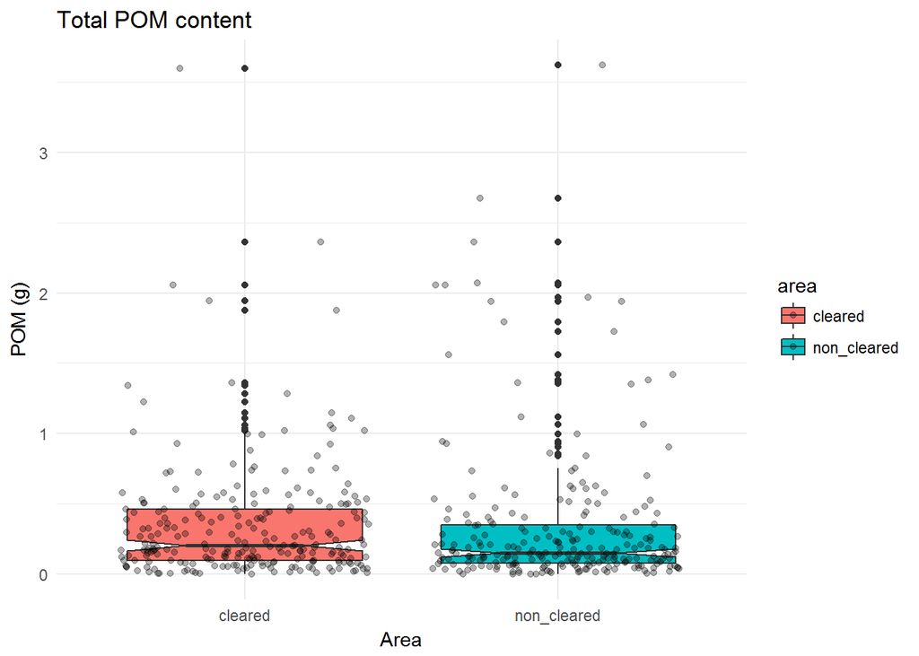

```r
plot1
```

```
## notch went outside hinges. Try setting notch=FALSE.
## notch went outside hinges. Try setting notch=FALSE.
## notch went outside hinges. Try setting notch=FALSE.
## notch went outside hinges. Try setting notch=FALSE.
```

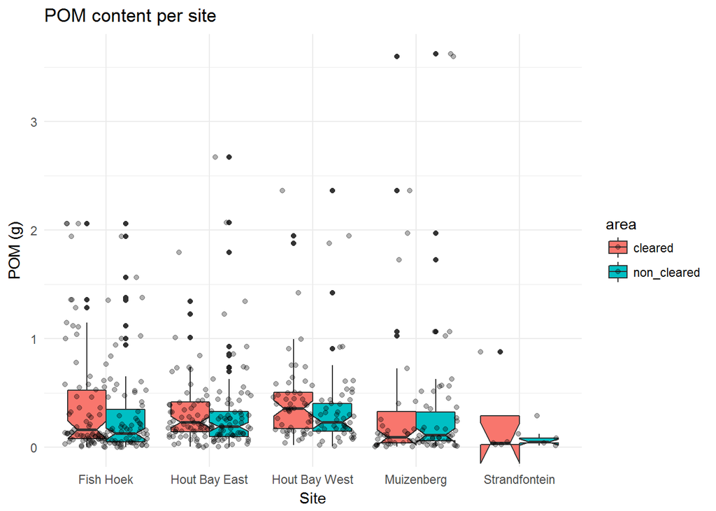

```r
plot2
```

```
## notch went outside hinges. Try setting notch=FALSE.
## notch went outside hinges. Try setting notch=FALSE.
```

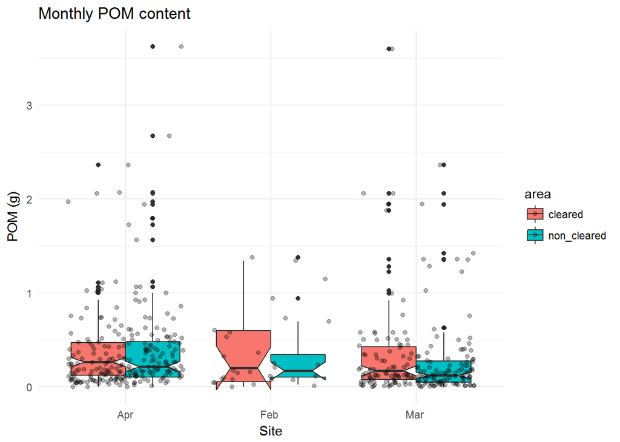

```r
plot3
```

```
## notch went outside hinges. Try setting notch=FALSE.
```

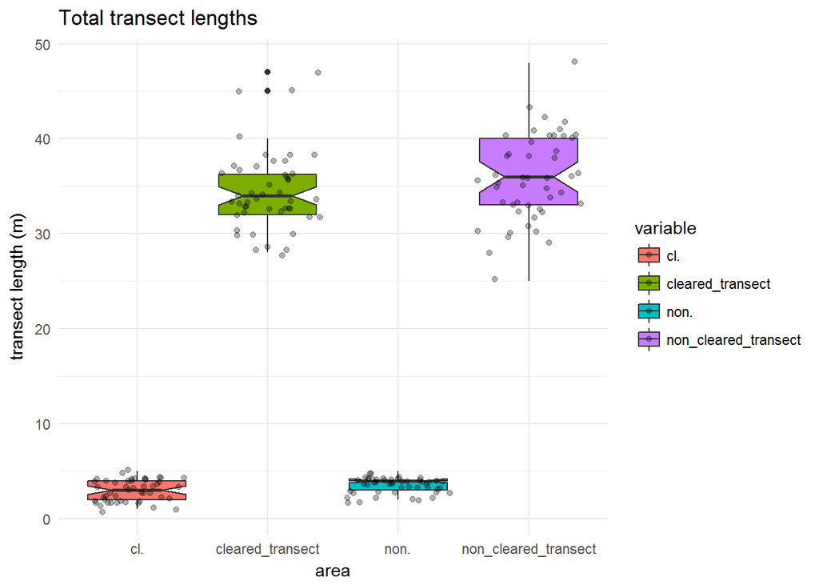

```r
plot4
```

```
## notch went outside hinges. Try setting notch=FALSE.
## notch went outside hinges. Try setting notch=FALSE.
## notch went outside hinges. Try setting notch=FALSE.
## notch went outside hinges. Try setting notch=FALSE.
```

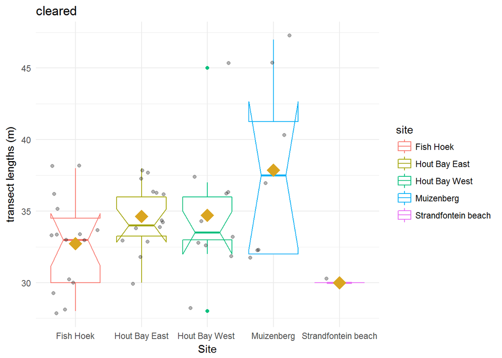

```r
plot5
```

```
## notch went outside hinges. Try setting notch=FALSE.
## notch went outside hinges. Try setting notch=FALSE.
## notch went outside hinges. Try setting notch=FALSE.
```

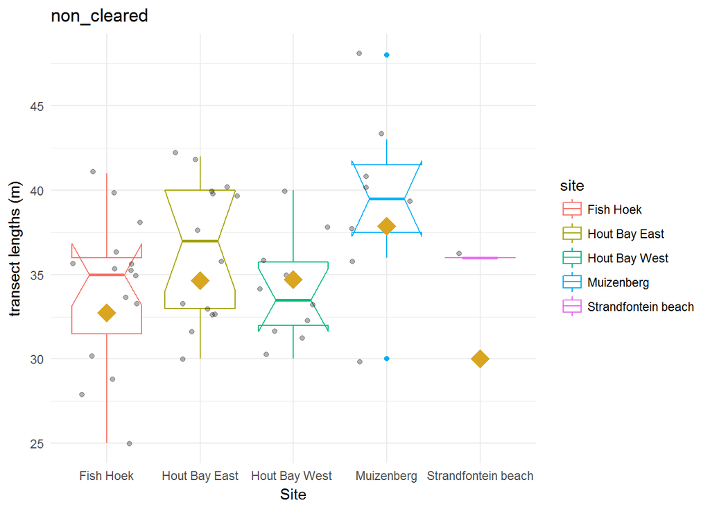

```r
plot6
```